# SPPH 504 Section 007 Lab 11: Analyzing Longitudinal Data (Part A): Mixed Effects Models

Ehsan Karim and Derek Ouyang

01 May 2020

# 1 Repeated measures

- Ref: (Faraway 2016) Section 9.2

In repeated measurement design, the response variable are measured multiple times for each individuals

# 2 Linear Mixed Effects Models for Repeated Measures Data

- Ref: (Everitt and Hothorn 2009) Section 12.4
- The linear mixed effect models are based on the idea that the correlation of an individual’s responses depends on some unobserved individual characteristics.
- In linear mixed effect models, we treat these unobserved characteristics as random effects in our model. If we could conditional on the random effects, then the repeated measurements can be assumed to be independent

## 2.1 Data

We are going to use the following dataset to explain the linear mixed effect model:

```r
library(HSAUR2)
data("BtheB")
kable(head(BtheB))%>%
  kable_styling(bootstrap_options = "striped", full_width = F, position = "left")
```

| drug | length | treatment | bdi.pre | bdi.2m | bdi.3m | bdi.5m | bdi.8m |
| --- | --- | --- | --- | --- | --- | --- | --- |
| No | >6m | TAU | 29 | 2 | 2 | NA | NA |
| Yes | >6m | BtheB | 32 | 16 | 24 | 17 | 20 |
| Yes | <6m | TAU | 25 | 20 | NA | NA | NA |
| No | >6m | BtheB | 21 | 17 | 16 | 10 | 9 |
| Yes | >6m | BtheB | 26 | 23 | NA | NA | NA |
| Yes | <6m | BtheB | 7 | 0 | 0 | 0 | 0 |

- A typical form of repeated measurement data from a clinical trial data.
- The individuals are allocated to different treatments then the response Beck Depression Inventory II were taken at baseline, 2, 3, 5, and 8mths

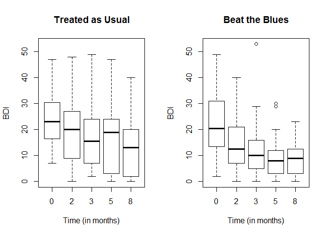

```r
## Box-plot of responses at different time points in trt and control groups
data("BtheB", package = "HSAUR2")
layout(matrix(1:2, nrow = 1))
ylim <- range(BtheB[,grep("bdi", names(BtheB))],na.rm = TRUE)
tau <- subset(BtheB, treatment == "TAU")[, grep("bdi", names(BtheB))]
boxplot(tau, main = "Treated as Usual", ylab = "BDI",xlab = "Time (in months)",
        names = c(0, 2, 3, 5, 8),ylim = ylim)
btheb <- subset(BtheB, treatment == "BtheB")[, grep("bdi", names(BtheB))]
boxplot(btheb, main = "Beat the Blues", ylab = "BDI",xlab = "Time (in months)",
        names = c(0, 2, 3, 5, 8),ylim = ylim)
```

- The side-by-side boxplots show the dustributions of BDI overtime between control (Treated as Usual) and intervention (Beat the Blues) groups.
- As time goes, drops in BDI are more obvious in intervention which may indicate the intervention is effective.

## 2.2 Regular model fixed intercept and slope

To compare, we start with fixed effect linear model

```r
## To analyze the data, we first need to convert the dataset to a analysis-ready form
BtheB$subject <- factor(rownames(BtheB))
nobs <- nrow(BtheB)
BtheB_long <- reshape(BtheB, idvar = "subject",
                      varying = c("bdi.2m", "bdi.3m", "bdi.5m", "bdi.8m"),
                      direction = "long")
BtheB_long$time <- rep(c(2, 3, 5, 8), rep(nobs, 4))
kable(head(BtheB_long))%>%
  kable_styling(bootstrap_options = "striped", full_width = F, position = "left")
```

|  | drug | length | treatment | bdi.pre | subject | time | bdi |
| --- | --- | --- | --- | --- | --- | --- | --- |
| 1.2m | No | >6m | TAU | 29 | 1 | 2 | 2 |
| 2.2m | Yes | >6m | BtheB | 32 | 2 | 2 | 16 |
| 3.2m | Yes | <6m | TAU | 25 | 3 | 2 | 20 |
| 4.2m | No | >6m | BtheB | 21 | 4 | 2 | 17 |
| 5.2m | Yes | >6m | BtheB | 26 | 5 | 2 | 23 |
| 6.2m | Yes | <6m | BtheB | 7 | 6 | 2 | 0 |

```r
unique(BtheB_long$subject)
```

```
##   [1] 1   2   3   4   5   6   7   8   9   10  11  12  13  14  15  16  17
##  [18] 18  19  20  21  22  23  24  25  26  27  28  29  30  31  32  33  34
##  [35] 35  36  37  38  39  40  41  42  43  44  45  46  47  48  49  50  51
##  [52] 52  53  54  55  56  57  58  59  60  61  62  63  64  65  66  67  68
##  [69] 69  70  71  72  73  74  75  76  77  78  79  80  81  82  83  84  85
##  [86] 86  87  88  89  90  91  92  93  94  95  96  97  98  99  100
## 100 Levels: 1 10 100 11 12 13 14 15 16 17 18 19 2 20 21 22 23 24 25 ... 99
```

```r
kable(subset(BtheB_long,  subject == 2))%>%
  kable_styling(bootstrap_options = "striped", full_width = F, position = "left")
```

|  | drug | length | treatment | bdi.pre | subject | time | bdi |
| --- | --- | --- | --- | --- | --- | --- | --- |
| 2.2m | Yes | >6m | BtheB | 32 | 2 | 2 | 16 |
| 2.3m | Yes | >6m | BtheB | 32 | 2 | 3 | 24 |
| 2.5m | Yes | >6m | BtheB | 32 | 2 | 5 | 17 |
| 2.8m | Yes | >6m | BtheB | 32 | 2 | 8 | 20 |

```r
kable(subset(BtheB_long,  subject == 99))%>%
  kable_styling(bootstrap_options = "striped", full_width = F, position = "left")
```

|  | drug | length | treatment | bdi.pre | subject | time | bdi |
| --- | --- | --- | --- | --- | --- | --- | --- |
| 99.2m | No | <6m | TAU | 13 | 99 | 2 | 5 |
| 99.3m | No | <6m | TAU | 13 | 99 | 3 | 5 |
| 99.5m | No | <6m | TAU | 13 | 99 | 5 | 0 |
| 99.8m | No | <6m | TAU | 13 | 99 | 8 | 6 |

```r
lmfit <- lm(bdi ~ bdi.pre + time + treatment + drug +length, data = BtheB_long,
                    na.action = na.omit)
require(jtools)
summ(lmfit)
```

| Observations | 280 (120 missing obs. deleted) |
| --- | --- |
| Dependent variable | bdi |
| Type | OLS linear regression |

| F(5,274) | 35.78 |
| --- | --- |
| R² | 0.40 |
| Adj. R² | 0.38 |

|  | Est. | S.E. | t val. | p |  |
| --- | --- | --- | --- | --- | --- |
| (Intercept) | 7.32 | 1.73 | 4.24 | 0.00 | *** |
| bdi.pre | 0.57 | 0.05 | 10.44 | 0.00 | *** |
| time | -0.94 | 0.24 | -3.97 | 0.00 | *** |
| treatmentBtheB | -3.32 | 1.10 | -3.02 | 0.00 | ** |
| drugYes | -3.57 | 1.15 | -3.11 | 0.00 | ** |
| length>6m | 1.71 | 1.11 | 1.54 | 0.12 |  |

Standard errors: OLS

## 2.3 Random intercept but fixed slope

- First, we can consider to add a random intercept to the model.
- The resulting regression line for each individual is parallel but have different intercepts

```r
## Fit a random intercept model with lme4 package
library("lme4")
BtheB_lmer1 <- lmer(bdi ~ bdi.pre + time + treatment + drug +length
                    + (1 | subject), data = BtheB_long, REML = FALSE,
                    na.action = na.omit)

summary(BtheB_lmer1)
```

```
## Linear mixed model fit by maximum likelihood  ['lmerMod']
## Formula: bdi ~ bdi.pre + time + treatment + drug + length + (1 | subject)
##    Data: BtheB_long
##
##      AIC      BIC   logLik deviance df.resid
##   1887.5   1916.6   -935.7   1871.5      272
##
## Scaled residuals:
##     Min      1Q  Median      3Q     Max
## -2.6975 -0.5026 -0.0638  0.4124  3.8203
##
## Random effects:
##  Groups   Name        Variance Std.Dev.
##  subject  (Intercept) 48.78    6.984
##  Residual             25.14    5.014
## Number of obs: 280, groups:  subject, 97
##
## Fixed effects:
##                Estimate Std. Error t value
## (Intercept)     5.59239    2.24244   2.494
## bdi.pre         0.63968    0.07789   8.212
## time           -0.70476    0.14639  -4.814
## treatmentBtheB -2.32908    1.67036  -1.394
## drugYes        -2.82495    1.72684  -1.636
## length>6m       0.19708    1.63832   0.120
##
## Correlation of Fixed Effects:
##             (Intr) bdi.pr time   trtmBB drugYs
## bdi.pre     -0.682
## time        -0.238  0.020
## tretmntBthB -0.390  0.121  0.018
## drugYes     -0.073 -0.237 -0.022 -0.323
## length>6m   -0.243 -0.242 -0.036  0.002  0.157
```

```r
summ(BtheB_lmer1)
```

| Observations | 280 |
| --- | --- |
| Dependent variable | bdi |
| Type | Mixed effects linear regression |

| AIC | 1887.49 |
| --- | --- |
| BIC | 1916.57 |
| Pseudo-R² (fixed effects) | 0.39 |
| Pseudo-R² (total) | 0.79 |

| Fixed Effects | Fixed Effects Est. | Fixed Effects S.E. | Fixed Effects t val. | Fixed Effects d.f. | Fixed Effects p | Fixed Effects |
| --- | --- | --- | --- | --- | --- | --- |
| (Intercept) | 5.59 | 2.24 | 2.49 | 108.98 | 0.01 | * |
| bdi.pre | 0.64 | 0.08 | 8.21 | 104.08 | 0.00 | *** |
| time | -0.70 | 0.15 | -4.81 | 199.32 | 0.00 | *** |
| treatmentBtheB | -2.33 | 1.67 | -1.39 | 97.12 | 0.17 |  |
| drugYes | -2.82 | 1.73 | -1.64 | 98.20 | 0.11 |  |
| length>6m | 0.20 | 1.64 | 0.12 | 100.26 | 0.90 |  |

p values calculated using Satterthwaite d.f.

| Random Effects Group | Random Effects Parameter | Random Effects Std. Dev. |
| --- | --- | --- |
| subject | (Intercept) | 6.98 |
| Residual |  | 5.01 |

| Grouping Variables Group | Grouping Variables # groups | Grouping Variables ICC |
| --- | --- | --- |
| subject | 97 | 0.66 |

- AIC, BIC, and -loglik etc are goodness-of-fit statistics, which tells you how well the model fits your data. Since there is no standard to tell what values of these statistics are good, without comparison with other models, they have little information to tell
- Fixed effects: this is the standard output we will have in any fixed-effect model. The interpretation of estimated coefficients will be similar to a regular linear model.
- You may compare the outputs with the regular linear model, then you will find that **lm** tends to **underestimate** the SE for estimated coefficients

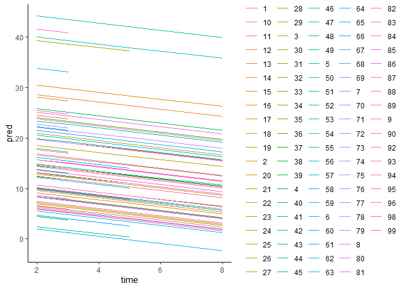

```r
library(ggplot2)
BtheB_longna <- na.omit(BtheB_long)
dat <- data.frame(time=BtheB_longna$time,pred=fitted(BtheB_lmer1),Subject= BtheB_longna$subject)
ggplot(data=dat,aes(x=time, y=pred, group=Subject, color=Subject)) + theme_classic() +
    geom_line()
```

- For each individual, the have different intercepts but the slope for time is the same.

## 2.4 Random slope and random intercept

- Now, we can consider to add both random intercept and random slope to the model.

```r
## We can fit a random slope and intercept model using lme4 package and treat variable time as random slope.
library("lme4")
BtheB_lmer2 <- lmer(bdi ~ bdi.pre + time + treatment + drug +length +
                   (time | subject), data = BtheB_long, REML = FALSE,
                   na.action = na.omit)

summ(BtheB_lmer2)
```

| Observations | 280 |
| --- | --- |
| Dependent variable | bdi |
| Type | Mixed effects linear regression |

| AIC | 1891.04 |
| --- | --- |
| BIC | 1927.39 |
| Pseudo-R² (fixed effects) | 0.39 |
| Pseudo-R² (total) | 0.80 |

| Fixed Effects | Fixed Effects Est. | Fixed Effects S.E. | Fixed Effects t val. | Fixed Effects d.f. | Fixed Effects p | Fixed Effects |
| --- | --- | --- | --- | --- | --- | --- |
| (Intercept) | 5.61 | 2.25 | 2.50 | 106.79 | 0.01 | * |
| bdi.pre | 0.64 | 0.08 | 8.25 | 102.78 | 0.00 | *** |
| time | -0.70 | 0.15 | -4.56 | 57.70 | 0.00 | *** |
| treatmentBtheB | -2.38 | 1.67 | -1.42 | 97.12 | 0.16 |  |
| drugYes | -2.87 | 1.73 | -1.66 | 98.18 | 0.10 | . |
| length>6m | 0.14 | 1.64 | 0.09 | 100.05 | 0.93 |  |

p values calculated using Satterthwaite d.f.

| Random Effects Group | Random Effects Parameter | Random Effects Std. Dev. |
| --- | --- | --- |
| subject | (Intercept) | 7.12 |
| subject | time | 0.43 |
| Residual |  | 4.90 |

| Grouping Variables Group | Grouping Variables # groups | Grouping Variables ICC |
| --- | --- | --- |
| subject | 97 | 0.68 |

- You may want to compare AIC, BIC etc with the first model, it seems that the first model is better as it has smaller AIC and BIC.
- The interpretation of the R outputs will be similar to the model with only random intercepts.

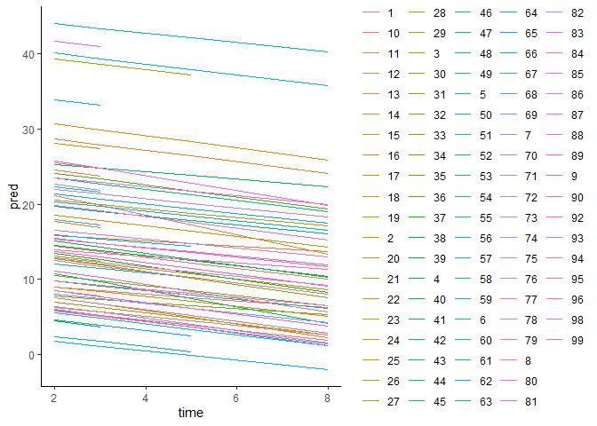

```r
library(ggplot2)
BtheB_longna <- na.omit(BtheB_long)
dat <- data.frame(time=BtheB_longna$time,pred=fitted(BtheB_lmer2),Subject= BtheB_longna$subject)
ggplot(data=dat,aes(x=time, y=pred, group=Subject, color=Subject)) + theme_classic() +
    geom_line()
```

## 2.5 Choice among models

A common question is to ask should I add random slope to our model or random intercept is good enough.

- **lm** usually will not be considered as a competitor of **lme** as they basically apply to different types of data.
- When choosing between random intercept and random slope, a quick solution is to fit all possible models then do likelihood ratio tests.
- For example, I am not sure whether I should use random intercept only or random intercept + random slope. I could fit both model, then do a likelihood ratio test:

```r
anova(BtheB_lmer1, BtheB_lmer2)
```

```
## Data: BtheB_long
## Models:
## BtheB_lmer1: bdi ~ bdi.pre + time + treatment + drug + length + (1 | subject)
## BtheB_lmer2: bdi ~ bdi.pre + time + treatment + drug + length + (time | subject)
##             Df    AIC    BIC  logLik deviance  Chisq Chi Df Pr(>Chisq)
## BtheB_lmer1  8 1887.5 1916.6 -935.75   1871.5
## BtheB_lmer2 10 1891.0 1927.4 -935.52   1871.0 0.4542      2     0.7969
```

```r
## The non-significant p-value shows that the second model is not
## statistically different from the first model. Therefore, adding a
## random slope is not necessary
```

The p-value is greater than 0.05, which indicate that adding a random slope does not make the fitting significantly better. To keep the model simple, we may just use random intercept

# 3 Prediction of Random Effects

- Ref: (Everitt and Hothorn 2009) Section 12.5

If you have noticed in the R output of linear mixed effect model. Random effects are not estimated in the model.

- We could use the fitted model to predict random effects.
- Also, the predicted random effects can be used to examine the assumptions we have for linear mixed effect model.

**ranef** is used to predict the random effect in R

```r
qint <- ranef(BtheB_lmer1)$subject[["(Intercept)"]]
qint
```

```
##  [1] -16.36173375  -2.44276821  -3.81655246   3.05333922   3.45142238
##  [6]   7.76598367   2.72263772  -7.22484559   6.84680602  -1.02552079
## [11]   2.40417045   1.16611116  -8.55346514  -6.25844460  -2.26117890
## [16]  -5.23031326   2.52509369  -1.64263852  -1.07523647   3.93689149
## [21]   7.66903463 -16.38156570   1.74883169  -1.31871405  -9.02883840
## [26]  -2.75150748   2.38884153   2.72740396  -3.41918532   6.27519223
## [31]  -4.52154803  -8.67437212  -0.34470205  -0.63972052  -0.08927192
## [36]   7.61914258   2.91050410  -2.58455316   4.24637600 -16.01664339
## [41]   5.90993760   3.21014015  -7.04631384   3.09608814   4.71327693
## [46]  16.70161317   2.26241515   2.26584469  15.77002931   1.75410837
## [51]   6.18741462   1.99791718   0.56774361   4.04107961  10.72891284
## [56]  -1.54551022  -5.28330188   2.04552522   2.36472052  -1.56879949
## [61]   6.63565622   5.45929307  -4.19695092  -6.39632477  -2.21496277
## [66]  -0.95956131  -3.96021844   7.17628694  -1.41644514  -4.99763131
## [71]  -2.83374089  -1.28015490   8.79345975  -0.33213424   1.43146351
## [76]  -3.13316289  -6.52989436   2.51445568   5.93414995   3.42003750
## [81]   4.49954787   3.75178694  -6.44832885  12.88173193  -9.36110799
## [86]   2.02028145 -18.09960217  -6.53428519   5.06613704  -3.31816903
## [91]   7.26187433   0.03103105  -8.14350170  -4.89326756   2.92437697
## [96]   5.24835920  -5.96778936
```

```r
## predict random effects using the fitted model
```

# 4 Check assumptions

Remeber, we have two assumptions in the linear mixed effect model with random intercept:

- error term follows normal distribution
- beta for subject i follows normal distribution

We have predict the values of random effect and we could extract residuals from the fitted model. Therefore, we can use QQ-plot to check their normality

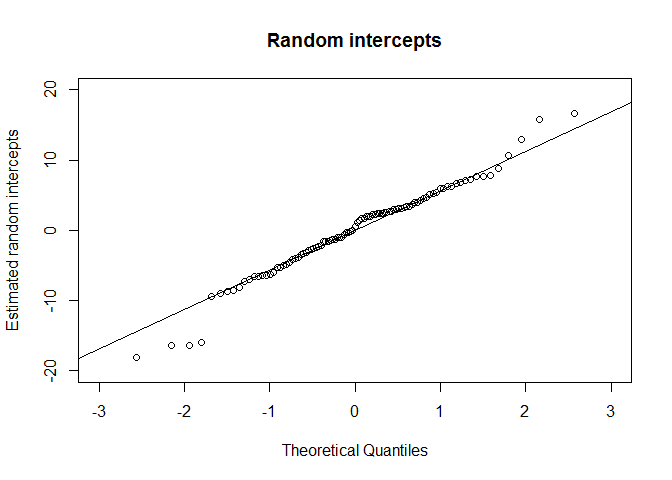

```r
## Check assumptions
qint <- ranef(BtheB_lmer1)$subject[["(Intercept)"]]
qres <- residuals(BtheB_lmer1)
qqnorm(qint, ylab = "Estimated random intercepts", xlim = c(-3, 3), ylim = c(-20, 20),
       main = "Random intercepts")
qqline(qint)
```

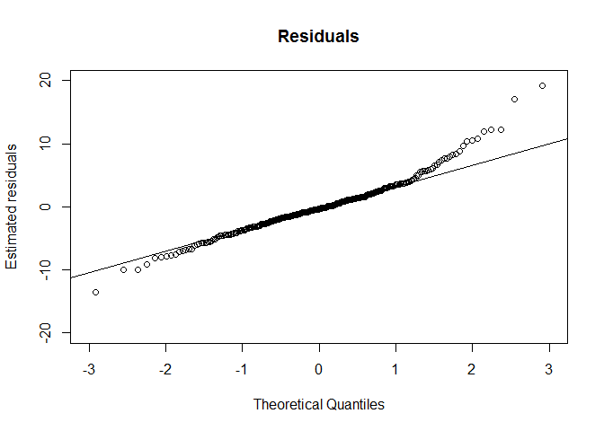

```r
qqnorm(qres, xlim = c(-3, 3), ylim = c(-20, 20), ylab = "Estimated residuals",
       main = "Residuals")
qqline(qres)
```

- Since points are almost on the lines, the normality assumption checked!

# Reference

Everitt, Brian S, and Torsten Hothorn. 2009. “A Handbook of Statistical Analyses Using R. 2009; Second Edition.” Chapman & Hall/CRC Press Binding.

Faraway, Julian J. 2016. *Extending the Linear Model with R: Generalized Linear, Mixed Effects and Nonparametric Regression Models*. Chapman; Hall/CRC.